# Differential expression of genes and modules

J. Shah chimeric mouse collaboration

Kim Dill-McFarland, kadm@uw.edu

version May 13, 2020

# Background

The purpose of this workflow is to identify differentially expressed (DE) genes and modules.

# Setup

Load packages

```r
# Data manipulation and figures
library(tidyverse)
    # Multi-panel figures for ggplot
    library(cowplot)

#Define ggplot colors
logFC.cols <- c("Down, FDR < 0.5"="lightblue",
                "Down, FDR < 0.2"="blue",
                "Down, FDR < 0.05"="darkblue",
                "NS"="grey",
                "Up, FDR < 0.5"="pink",
                "Up, FDR < 0.2"="red",
                "Up, FDR < 0.05"="darkred")

#Linear models
library(limma)
#Construct networks to ID modules
library(WGCNA)
# Print tty table to knit file
library(knitr)
library(kableExtra)
options(knitr.kable.NA = '')
```

Set seed

```r
set.seed(4389)
```

Scripts

```r
source("https://raw.githubusercontent.com/kdillmcfarland/R_bioinformatic_scripts/master/RNAseq_module_fxn.R")
source("https://raw.githubusercontent.com/kdillmcfarland/R_bioinformatic_scripts/master/limma.extract.pval.R")
source("scripts/RNAseq_boxplot_fxn.R")

`%notin%` <- Negate(`%in%`)
```

Set variable names and cutoffs for this workflow.

```r
#Rdata file WITHIN project directory that holds cleaned data
data.file <- "data_clean/Shah.clean.RData"

#Prefix to give file names
basename <- "Shah_contrast"
#Define variable(s) of interest
#Used in PCA plots and to select significant genes to be used in module building
vars_of_interest <- c("status","cell")

#Maximum fdr for genes to be included in plots and modules
gene.fdr.cutoff <- 0.5
```

# Load data

```r
#Load data
load(data.file)
```

This includes in the following samples.

| status | cell | n |
| --- | --- | --- |
| Uninfected | WT | 4 |
| Uninfected | TKO | 4 |
| Infected | WT | 4 |
| Infected | TKO | 4 |

# Data exploration

## PCA (genes)

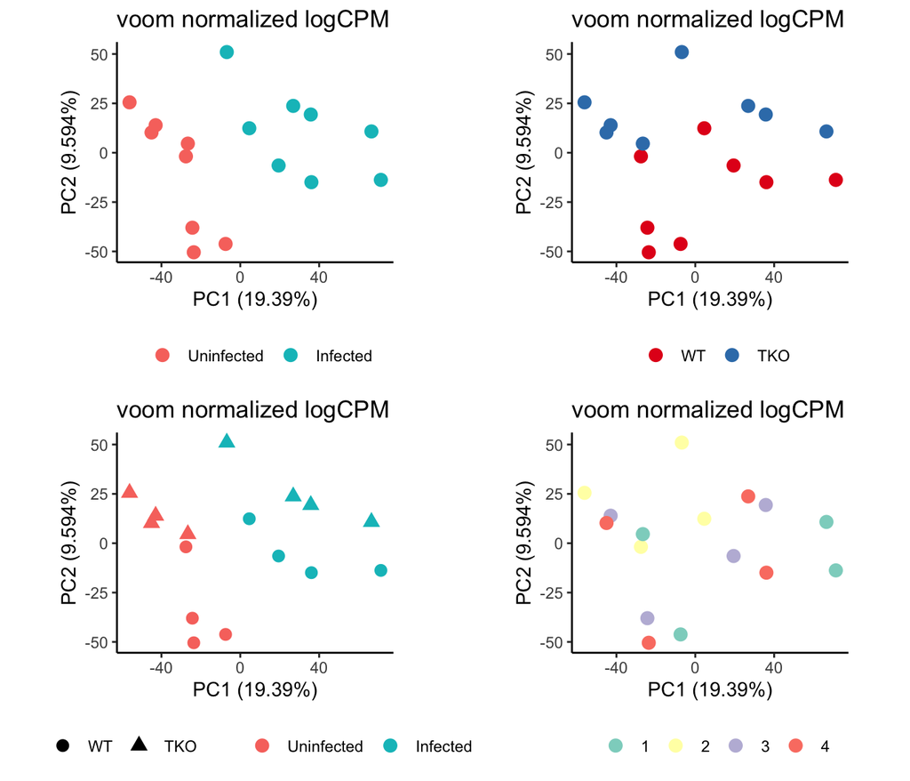

# Define significant genes

## Linear model

```r
# Define model
model <- model.matrix(~0 + status:cell, data=dat.voom$targets)
    colnames(model) <- c("Uninfected_WT", "Infected_WT",
                         "Uninfected_TKO", "Infected_TKO")
# Define contrasts of interest
contrasts <- makeContrasts(
  uninfected = Uninfected_TKO-Uninfected_WT,
  infected = Infected_TKO-Infected_WT,
  levels=model)

#Fit model to transformed count data. Calculate eBayes
  efitQW <- eBayes(
            contrasts.fit(contrasts=contrasts,
            lmFit(dat.voom$E, model)))
```

### Summarize gene model

| Variable | Comparison | Genes with FDR < 0.05 | Genes with FDR < 0.1 | Genes with FDR < 0.2 | Genes with FDR < 0.3 | Genes with FDR < 0.4 | Genes with FDR < 0.5 |
| --- | --- | --- | --- | --- | --- | --- | --- |
| uninfected | TKO-WT | 157 | 346 | 768 | 1391 | 2220 | 3380 |
| infected | TKO-WT | 194 | 645 | 1817 | 3084 | 4292 | 5391 |
| total (nonredundant) | TKO-WT | 306 | 882 | 2297 | 3899 | 5485 | 7108 |

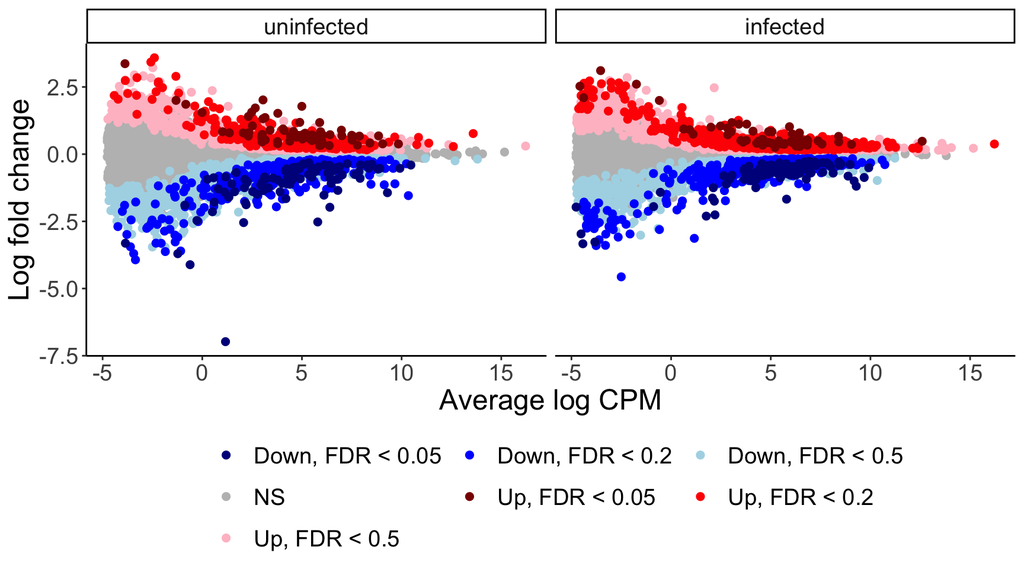

### Compare significant genes

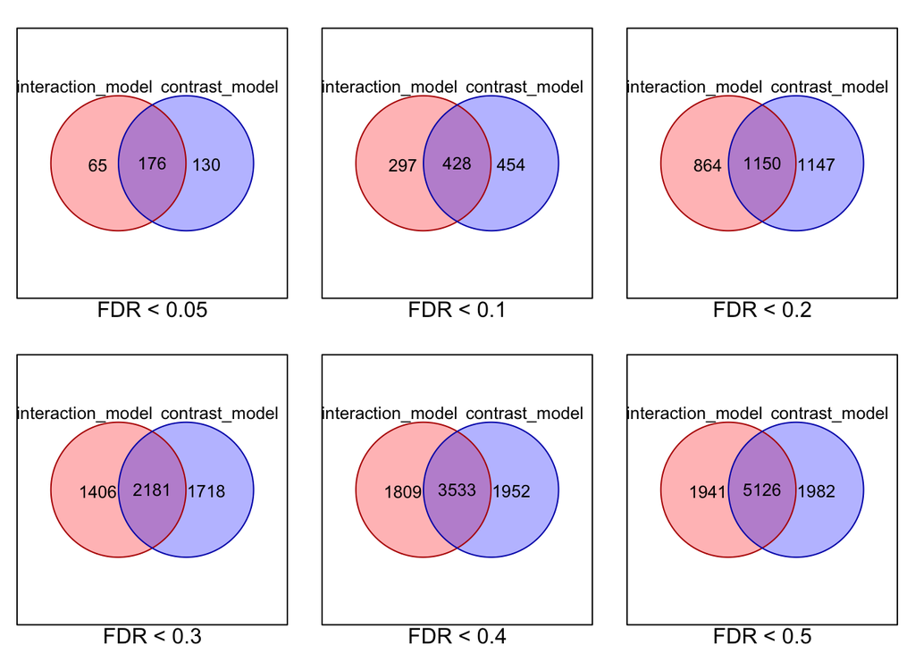

| FDR | model | genes not signif in other model | variable(s) those gene are signif for in this model |
| --- | --- | --- | --- |
| 0.05 | interaction | 65 | status |
| 0.05 | contrast | 130 | infected |
| 0.10 | interaction | 297 | status |
| 0.10 | contrast | 454 | infected |
| 0.20 | interaction | 864 | status |
| 0.20 | contrast | 1147 | infected |
| 0.30 | interaction | 1406 | status |
| 0.30 | contrast | 1718 | infected |
| 0.40 | interaction | 1809 | status |
| 0.40 | contrast | 1952 | infected |
| 0.50 | interaction | 1941 | status |
| 0.50 | contrast | 1982 | infected |

Roughly half of genes identified as significant in either model are also significant in the other model. Genes unique to the interaction model are only significant for infection `status`. Thus, the contrasts model appears to be successfully removing much of the infection-only signal while retaining all `cell` type and `status:cell` interaction signals.

Interestingly the genes unique to the contrasts model were only significant for cell type within `infected` cells. This may indicate that the contrasts model is better resolving signal from the interaction term `status:cell` since the interaction model defines the interaction from the intercept of `status` = uninfected and `cell` = WT.

Overall, these results indicate that the contrasts model better resolves the signals of interest.

## Gene plots

Save in `figs/gene_level_contrast`

# Modules: Status and cell

Define customizations for module building.

```r
#Set FDR cutoff for gene inclusion in modules
mod.fdr.cutoff <- 0.3
#List variables from which significant genes will be extracted
vars_for_mods <- c("uninfected","infected")
```

In total, 3899 of 14215 genes that significantly differed (FDR $\leq$ 0.3) by one or more variables of interest will be incorporated into gene modules.

```r
make.modules(voom.dat = dat.voom,
             genes.signif = genes.signif,
             Rsq.min = 0.8,
             minModuleSize = 50,
             deepSplit = 3,
             nThread = 4,
             basename = basename)
```

```
## Allowing multi-threading with up to 4 threads.
## pickSoftThreshold: will use block size 3899.
##  pickSoftThreshold: calculating connectivity for given powers...
##    ..working on genes 1 through 3899 of 3899
##    Power SFT.R.sq  slope truncated.R.sq mean.k. median.k. max.k.
## 1      1   0.0408 10.500          0.981 1950.00   1950.00 2020.0
## 2      2   0.0484  2.000          0.926 1170.00   1180.00 1350.0
## 3      3   0.0155 -0.520          0.882  785.00    788.00 1060.0
## 4      4   0.0445 -0.601          0.879  560.00    561.00  869.0
## 5      5   0.1020 -0.721          0.892  417.00    414.00  732.0
## 6      6   0.1910 -0.865          0.901  319.00    314.00  627.0
## 7      7   0.2810 -0.947          0.926  250.00    244.00  543.0
## 8      8   0.3660 -1.050          0.939  199.00    191.00  474.0
## 9      9   0.4550 -1.120          0.954  161.00    152.00  417.0
## 10    10   0.5230 -1.190          0.962  132.00    122.00  369.0
```

[output cut: 20 more lines]

A power threshold of 21 was used as it achieves high R<sup>2</sup> and sufficient mean connectivity (R<sup>2</sup> = 0.8015016, mean k = 24.8126884).

| Module | Total genes |
| --- | --- |
| 00 | 282 |
| 01 | 583 |
| 02 | 463 |
| 03 | 456 |
| 04 | 314 |
| 05 | 276 |
| 06 | 242 |
| 07 | 219 |
| 08 | 200 |
| 09 | 164 |
| 10 | 151 |
| 11 | 127 |
| 12 | 93 |
| 13 | 82 |
| 14 | 73 |
| 15 | 62 |
| 16 | 58 |
| 17 | 54 |

This created 17 modules plus 282 (7.2326237%) genes not grouped into any module (*e.g.* in module 0).

## PCA (modules)

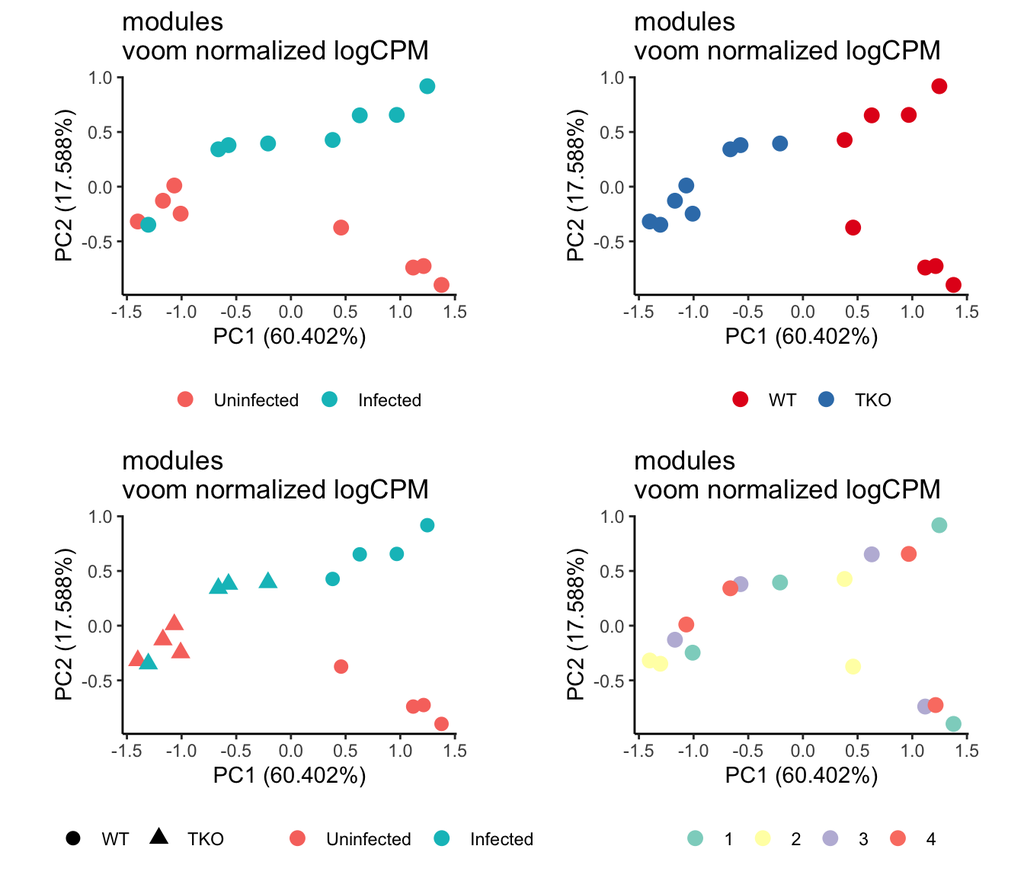

## Linear model

```r
# Fit model to transformed count data. Calculate eBayes
  efitQW.mods <- eBayes(
            contrasts.fit(contrasts=contrasts,
            lmFit(voom.mods, model)))
```

### Summarize module model

| Variable | Comparison | Modules with FDR < 0.05 | Modules with FDR < 0.1 | Modules with FDR < 0.2 | Modules with FDR < 0.3 | Modules with FDR < 0.4 | Modules with FDR < 0.5 |
| --- | --- | --- | --- | --- | --- | --- | --- |
| uninfected | TKO-WT | 13 | 14 | 14 | 17 | 17 | 17 |
| infected | TKO-WT | 14 | 15 | 16 | 16 | 17 | 18 |
| total (nonredundant) | TKO-WT | 18 | 18 | 18 | 18 | 18 | 18 |

| module | uninfected direction in TKO | infected direction in TKO |
| --- | --- | --- |
| **Significant in uninfected** |  |  |
| module_Shah_contrast_06 | down |  |
| module_Shah_contrast_12 | down |  |
| module_Shah_contrast_13 | up |  |
| module_Shah_contrast_15 | up |  |
| **Significant in infected** |  |  |
| module_Shah_contrast_04 |  | down |
| module_Shah_contrast_08 |  | down |
| module_Shah_contrast_01 |  | up |
| module_Shah_contrast_03 |  | up |
| **Significant in both** |  |  |
| module_Shah_contrast_05 | down | down |
| module_Shah_contrast_11 | down | down |
| module_Shah_contrast_17 | down | down |
| module_Shah_contrast_10 | down | down |
| module_Shah_contrast_02 | down | down |
| module_Shah_contrast_14 | up | up |
| module_Shah_contrast_07 | up | up |
| module_Shah_contrast_16 | up | up |
| module_Shah_contrast_09 | up | up |

*Directions are relative to WT. For example, `down` means the module has **lower** expression in TKO relative to WT.*

## Module plots

Create expression plots of modules, and save in `figs/module*`